# What does a subgroup look like?

D.E. Beaudette

2026-05-19

# 1 Introduction

[Soil Taxonomy](https://www.nrcs.usda.gov/wps/portal/nrcs/main/soils/survey/class/taxonomy/) is a theoretical framework for organizing soil information, typically at scales coarser than most land management decisions. Soil series are a practical (but limited in geographic scope) framework for organizing soil/landscape combinations close to the scale of land management decisions.

So, what is the practical manifestation of a single subgroup from Soil Taxonomy (*abruptic durixeralfs*), in terms of soil series concepts?

The following code, links, and notes may serve as a starting point for those interested in learning more about Soil Taxonomy. This is a work in progress.

```r
# AQP suite, be sure to use the development versions from GitHub
library(aqp)
library(soilDB)
library(sharpshootR)

# used for visualization
library(latticeExtra)
library(tactile)
library(cluster)
library(ape)
library(FactoMineR)

# mapping a subgroup
library(sf)
library(terra)
library(spData)
# library(rasterVis)
# library(viridisLite)

# subgroup "explainer"
library(SoilTaxonomy)

library(data.tree)
```

# 2 Examples

Get a snapshot of the Soil Classification database. This contains the current classification for all soil series.

```r
# latest version, synced quarterly
u <- 'https://github.com/ncss-tech/SoilWeb-data/raw/main/files/SC-database.csv.gz'
tf <- tempfile()
download.file(u, destfile = tf)
SC <- read.csv(tf, stringsAsFactors = FALSE)
```

Or, if you have a local installation of the NASIS Client.

```r
SC <- get_soilseries_from_NASIS()
```

Identify all of the soil series associated with a specific subgroup taxa: *abruptic durixeralfs* and download basic morphology and climate summaries via `fetchOSD`.

```r
# select series names for a single subgroup
SC <- SC[which(SC$taxsubgrp == 'abruptic durixeralfs'), ]
s <- SC$soilseriesname

# get OSD morphology and extended summaries
osd <- fetchOSD(soils = s, extended = TRUE)
```

## 2.1 ST Explainer

Explain subgroup taxa via [SoilTaxonomy](https://github.com/ncss-tech/SoilTaxonomy/tree/master/R_pkg) package.

```r
cat(explainST('abruptic durixeralfs'))
```

```
abruptic durixeralfs
|        |   |  |
abrupt textural change
         |   |  |
         presence of a duripan
             |  |
             xeric soil moisture regime
                soils with an argillic, kandic, or natric horizon
```

## 2.2 ST Hierarchy to the Subgroup Level

Automatic to the subgroup, via SoilTaxonomy package.

```r
taxonTree(c('durixeralfs', 'rhodoxeralfs'), special.chars = c("\u251c","\u2502", "\u2514", "\u2500 "))
```

```
Soil Taxonomy
 └─ alfisols
     └─ xeralfs
         ├─ durixeralfs
         │   ├─ natric durixeralfs
         │   ├─ vertic durixeralfs
         │   ├─ aquic durixeralfs
         │   ├─ abruptic haplic durixeralfs
         │   ├─ abruptic durixeralfs
         │   ├─ haplic durixeralfs
         │   └─ typic durixeralfs
         └─ rhodoxeralfs
             ├─ lithic rhodoxeralfs
             ├─ vertic rhodoxeralfs
             ├─ petrocalcic rhodoxeralfs
             ├─ calcic rhodoxeralfs
             ├─ inceptic rhodoxeralfs
             └─ typic rhodoxeralfs
```

## 2.3 ST Hierarchy with Family and Series

We have to do this manually.

```r
# subset SC database to required columns
SC <- SC[, c('soilseriesname', 'taxorder', 'taxsuborder', 'taxgrtgroup', 'taxsubgrp', 'taxclname')]

# normalization via lower case
SC$taxclname <- tolower(SC$taxclname)
SC$soilseriesname <- tolower(SC$soilseriesname)

# remove subgroup component of family spec
SC$f <- NA_character_
for(i in 1:nrow(SC)) {
  SC$f[i] <- gsub(pattern = SC$taxsubgrp[i], replacement = '', SC$taxclname[i], fixed = TRUE)
}

# remove white space
SC$f <- trimws(SC$f, which = 'both')

# required columns only, smaller data.tree
v <- c('taxorder', 'taxsuborder', 'taxgrtgroup', 'taxsubgrp', 'f', 'soilseriesname', 'path')

# init data.tree object
SC$path <- sprintf("ST/%s/%s/%s/%s/%s/%s", SC$taxorder, SC$taxsuborder, SC$taxgrtgroup, SC$taxsubgrp, SC$f, SC$soilseriesname)
n <- as.Node(SC[, v], pathName = 'path')

## missing family / series result in an ugly tree, prune accordingly
# prune missing family / series
pf <- function(i) {

  # NA due to left join
  # note odd approach required, matching to 'NA' vs. is.na()
  if(GetAttribute(i, 'name') == 'NA') {
    return(FALSE)
  } else {
    return(TRUE)
  }

}

## print
# print(n, limit = NULL, pruneFun = pf)
```

```
                                                     levelName
1  ST
2   °--alfisols
3       °--xeralfs
4           °--durixeralfs
5               °--abruptic durixeralfs
6                   ¦--fine-loamy, mixed, superactive, thermic
7                   ¦   °--bellota
8                   ¦--ashy, glassy, frigid
9                   ¦   °--borealis
10                  ¦--fine, kaolinitic, thermic
11                  ¦   °--chesterton
12                  ¦--clayey-skeletal, kaolinitic, thermic
13                  ¦   °--clough
14                  ¦--very-fine, smectitic, frigid
```

[output cut: 25 more lines]

## 2.4 SoilWeb seriesTree Application

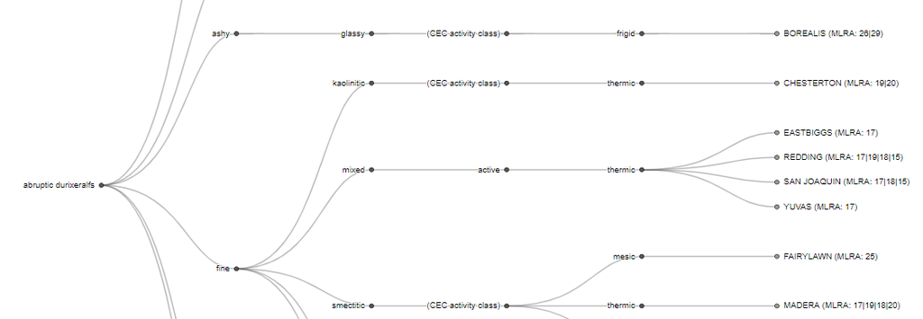

Link to SoilWeb subgroup taxa tree for [abruptic durixeralfs](https://casoilresource.lawr.ucdavis.edu/seriesTree/?subgroup=abruptic%20durixeralfs).

## 2.5 Taxa Extent Maps

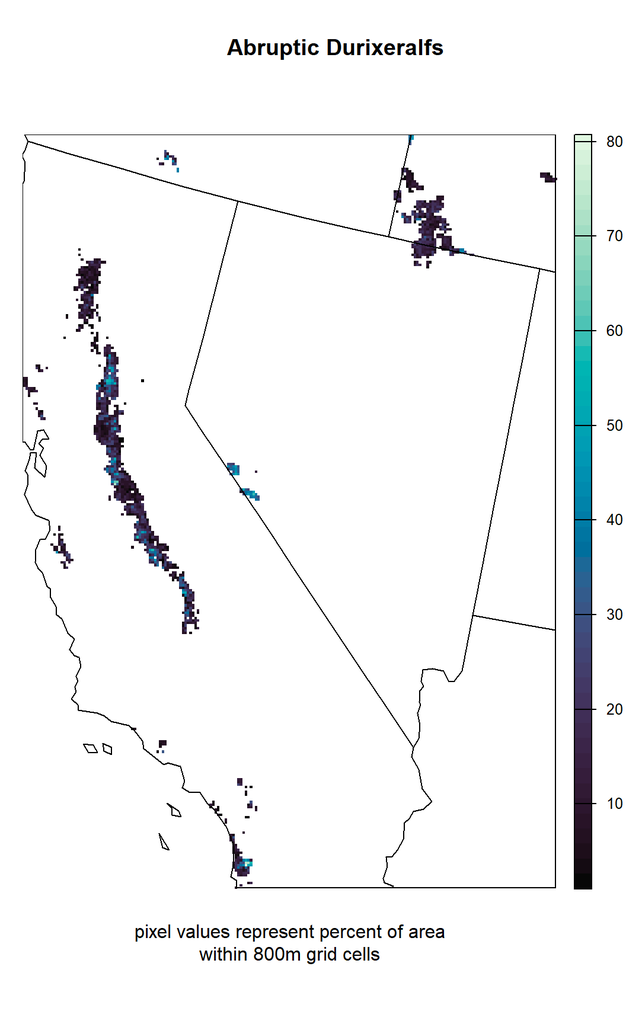

```r
# get 800m extent map
e <- taxaExtent('abruptic durixeralfs', level = 'subgroup')

# aggregate via focal mean using 5x5 moving window
# visualization purposes only
a <- terra::aggregate(e, fact = 5, fun = mean, na.rm = TRUE)

data("us_states")
us_states <- st_transform(us_states, 5070)
us_states <- st_crop(us_states, e)

# simple figure
plot(a, axes = FALSE, col = hcl.colors(n = 50, palette = 'mako'), mar = c(3, 1, 3, 3))
plot(st_geometry(us_states), add = TRUE)
title('Abruptic Durixeralfs')
mtext('pixel values represent percent of area\nwithin 800m grid cells', side = 1, line = 1.5)
```

## 2.6 Data via soilDB::fetchOSD

Cluster series based on annual climate summaries but don’t plot it yet.

```r
# control centers symbol and size here
res <- vizAnnualClimate(osd$climate.annual, s = 'SAN JOAQUIN', IQR.cex = 1.1, cex=1.1, pch=18)
```

Series associated with **abruptic durixeralfs** subgroup, arranged according to annual climate summaries.

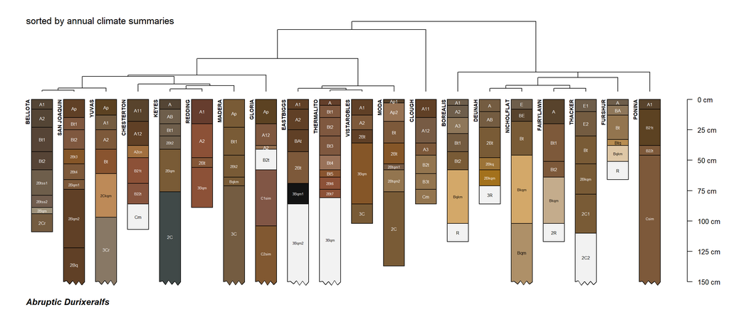

```r
par(mar = c(0,0,1,2))
plotProfileDendrogram(osd$SPC, clust = res$clust, scaling.factor = 0.075, width = 0.33, y.offset = 0.5, name.style = 'center-center', shrink = TRUE, max.depth = 150, depth.axis = list(cex = 0.8))
mtext('Abruptic Durixeralfs', side = 1, at = 0.5, adj = 0, line = -1.5, font=4)
mtext('sorted by annual climate summaries', side = 3, at = 0.5, adj = 0, line = -1.5, font = 1, cex = 1.1)
```

### 2.6.1 Annual climate summaries

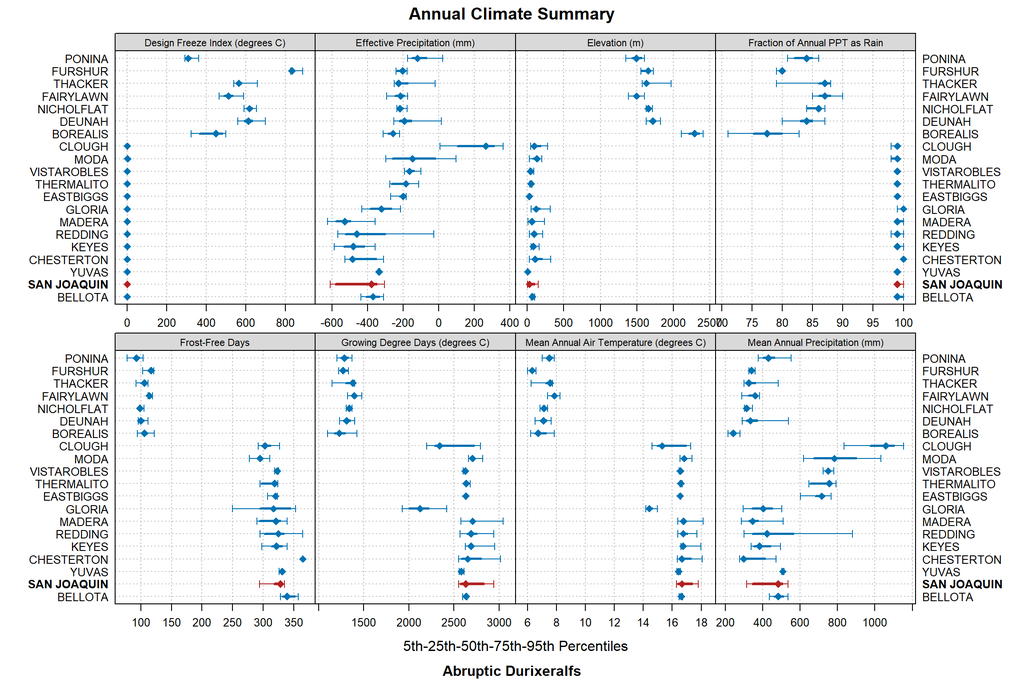

```r
# display annual climate summary
trellis.par.set(plot.line = list(col = 'RoyalBlue'))
print(update(res$fig, layout = c(4, 2), sub = 'Abruptic Durixeralfs'))
```

### 2.6.2 Geomorphic Descriptions

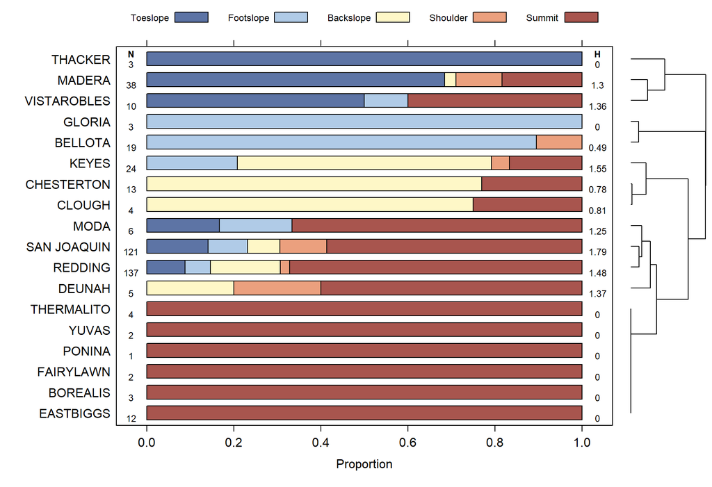

```r
hs <- vizHillslopePosition(osd$hillpos)
print(hs$fig)
```

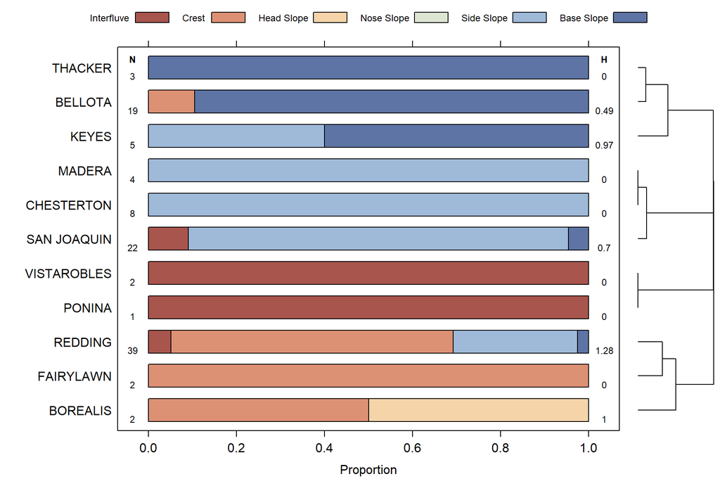

```r
gc <- vizGeomorphicComponent(osd$geomcomp)
print(gc$fig)
```

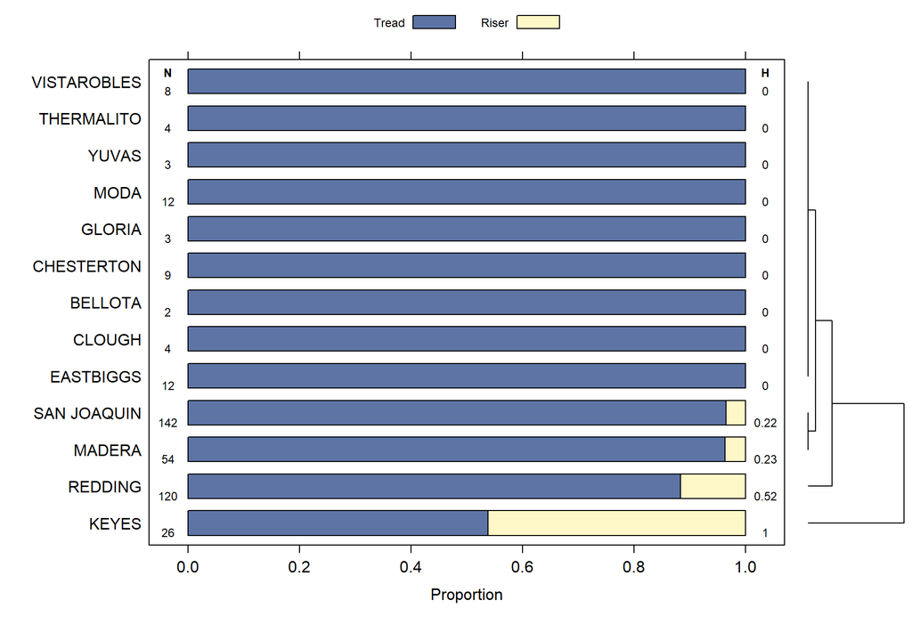

```r
tr <- vizTerracePosition(osd$terrace)
print(tr$fig)
```

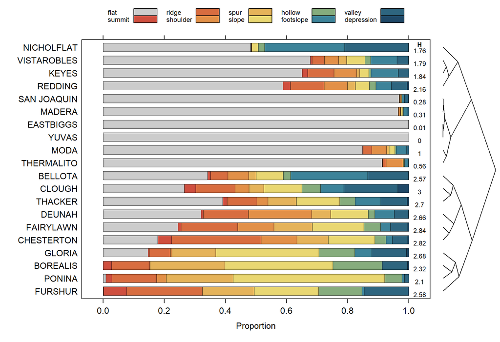

```r
tr <- vizGeomorphons(osd$geomorphons, dend.type = 'triangle')
print(tr$fig)
```

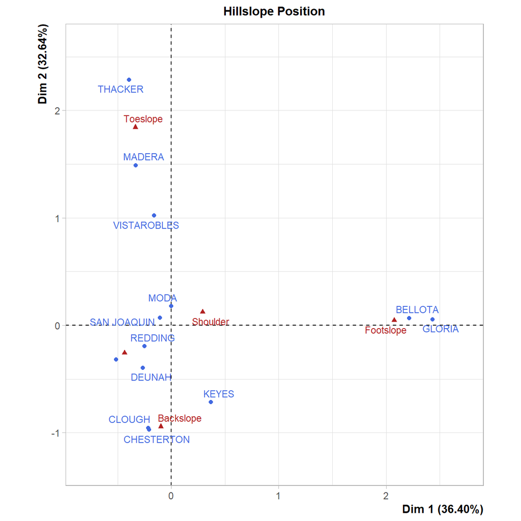

```r
hs.tab <- (osd$hillpos[, 2:6])
row.names(hs.tab) <- osd$hillpos$series

gc.tab <- (osd$geomcomp[, 2:7])
row.names(gc.tab) <- osd$geomcomp$series

hs.ca <- CA(hs.tab, graph = FALSE)
gc.ca <- CA(gc.tab, graph = FALSE)

plot(hs.ca, autoLab='yes', title='Hillslope Position', cex=0.75, col.col='firebrick', col.row='royalblue')
```

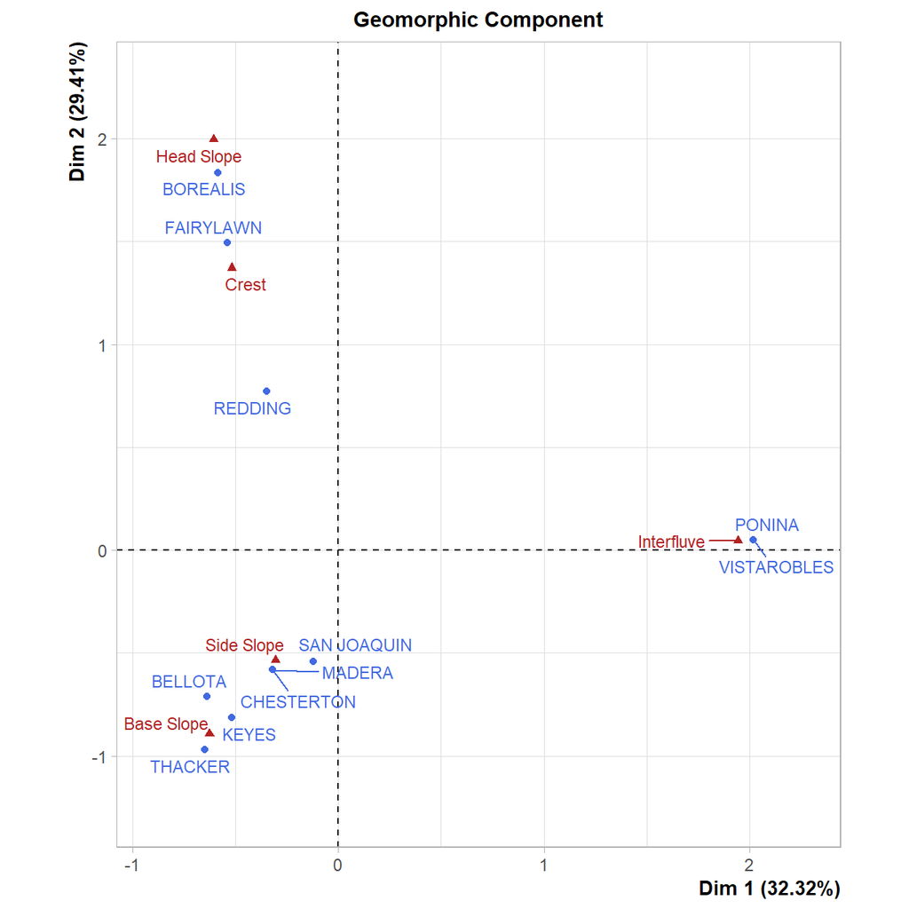

```r
plot(gc.ca, autoLab='yes', title='Geomorphic Component', cex=0.75, col.col='firebrick', col.row='royalblue')
```

### 2.6.3 Drainage Class

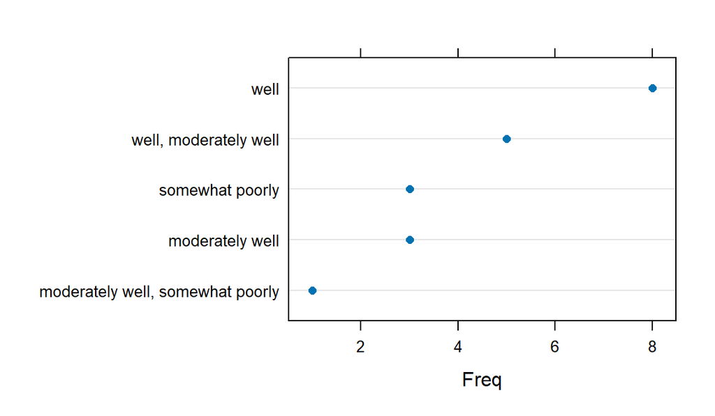

```r
# note that some series have multiple drainage class assigned
tab <- sort(table(osd$SPC$drainagecl))
dotplot(tab, par.setings = tactile.theme())
```

### 2.6.4 Depth Class

Include depth to silica-cemented horizons.

```r
sdc <- getSoilDepthClass(osd$SPC, p = c('Cr|R|Cd|qm'))
table(sdc$depth.class)
```

```
##
## very.shallow      shallow     mod.deep         deep    very.deep
##            0            3           12            2            3
```

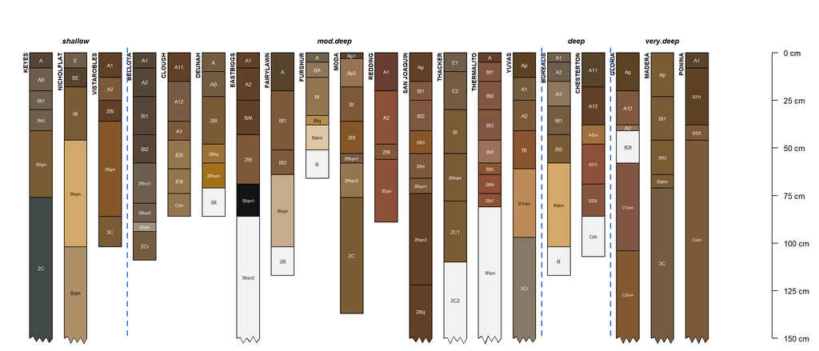

```r
site(osd$SPC) <- sdc

par(mar = c(0,0,1,2))
groupedProfilePlot(osd$SPC, groups = 'depth.class', name.style = 'center-center', width = 0.33, max.depth = 150, shrink = TRUE, depth.axis = list(cex = 0.8))
```

## 2.7 KSSL Data

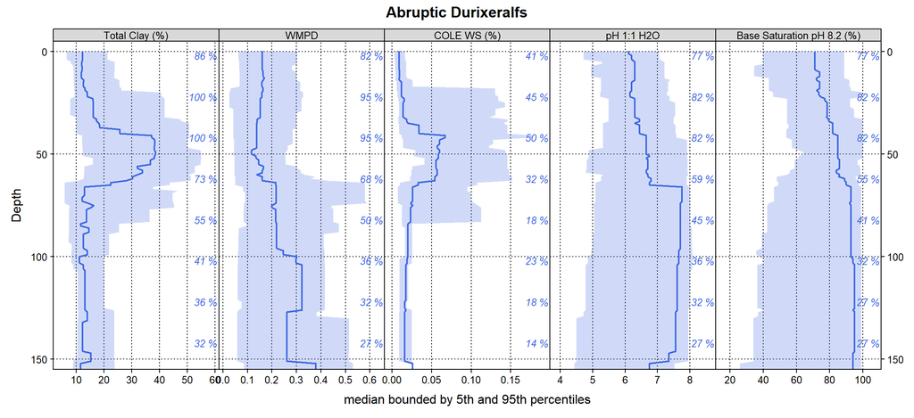

```r
# latest LDM snapshot, no soil morphologic data
lab <- fetchLDM(
  WHERE = "CASE WHEN corr_taxsubgrp IS NOT NULL THEN LOWER(corr_taxsubgrp) ELSE LOWER(samp_taxsubgrp) END = 'abruptic durixeralfs' "
)

# remove any profiles with horizon depth logic
lab <- HzDepthLogicSubset(lab)

length(lab)

# truncate profiles at 200cm
lab <- trunc(lab, 0, 200)

# # sanity check
# par(mar = c(0, 0, 3, 2))
# plotSPC(lab[1:15, ], print.id = FALSE, name = NA, width = 0.33, color = 'clay_total')

# weighted-mean particle diameter
lab$wmpd <- with(
  horizons(lab), ((sand_very_coarse * 1.5) + (sand_coarse * 0.75) + (sand_medium * 0.375) + (sand_fine * 0.175) + (sand_very_fine *0.075) + (silt_total * 0.026) + (clay_total * 0.0015)) / (sand_very_coarse + sand_coarse + sand_medium + sand_fine + sand_very_fine + silt_total + clay_total))

# estimate soil depth based on horizon designations
sdc <- getSoilDepthClass(lab)

# splice-into site data
site(lab) <- sdc

site(lab)$.grp <- factor('Abruptic Durixeralfs')
a <- slab(lab, .grp ~ clay_total + wmpd + cole_whole_soil + ph_h2o + base_sat_sum_of_cations_ph_8_2)

# re-name soil properties for clarity
a$variable <- factor(
  a$variable,
  labels = c('Total Clay (%)', 'WMPD', 'COLE WS (%)', 'pH 1:1 H2O', 'Base Saturation pH 8.2 (%)')
)

# define plotting style
tps <- tactile.theme(superpose.line=list(col=c('RoyalBlue', 'DarkRed', 'DarkGreen'), lwd=2))

# plot grouped, aggregate data
xyplot(top ~ p.q50 | variable,
       groups = .grp,
       data = a,
       ylab='Depth',
       xlab='median bounded by 5th and 95th percentiles',
       main = 'Abruptic Durixeralfs',
       lower=a$p.q5, upper=a$p.q95, ylim=c(155,-5),
       panel=panel.depth_function, alpha=0.25, sync.colors=TRUE,
       prepanel=prepanel.depth_function,
       cf=a$contributing_fraction,
       par.strip.text=list(cex=0.8),
       strip=strip.custom(bg=grey(0.85)),
       layout=c(5,1),
       scales=list(x=list(alternating=1, relation='free'), y=list(alternating=3)),
       par.settings=tps
)
```

## 2.8

### 2.8.1 ST Criteria via {aqp}

```r
# hasDarkColors(lab.spc, dhuenm = 'd_hue', dvalnm = 'd_value', dchrnm = 'd_chroma', mhuenm = 'm_hue', mvalnm = 'm_value', mchrnm = 'm_chroma')

# profileApply(lab.spc, getArgillicBounds, clay.attr = 'clay', texcl.attr = 'lab_texture_class', simplify = FALSE)
```

## 2.9 SoilWeb metadata

```r
kable_styling(kable(osd$soilweb.metadata, format = 'html', caption = 'SoilWeb Snapshot Metadata'), full_width = FALSE, font_size = 10)
```

SoilWeb Snapshot Metadata

| product | last_update |
| --- | --- |
| block diagram archive | 2025-01-21 |
| cached sketches | 2026-03-26 |
| component pedons | 2026-03-29 |
| ESID-series cross-tabulation | 2024-04-11 |
| ISSR800 | 2025-10-19 |
| KSSL snapshot | 2025-01-21 |
| MLRA membership | 2025-10-07 |
| mukey MLRA membership | 2025-01-22 |
| NASIS coiid LUT | 2026-03-29 |
| national musym LUT | 2026-03-29 |
| nationalmusym MLRA membership | 2025-01-22 |
| OSD fulltext | 2026-05-11 |
| OSD morphology | 2026-05-11 |
| SC database | 2026-05-11 |
| SDE cached figures | 2026-03-25 |
| series climate summary | 2025-10-08 |
| series-ESID cross-tabulation | 2024-04-11 |
| series extent | 2025-10-19 |
| series monthly water balance | 2025-10-08 |
| SeriesTree | 2026-05-11 |
| SSA vintage | 2025-10-03 |
| SSURGO geomorphology | 2026-01-11 |
| SSURGO geomorphon | 2026-01-11 |
| SSURGO NCCPI Stats | 2025-10-19 |
| SSURGO parent material | 2026-01-11 |
| SSURGO SOC Stocks | 2025-10-04 |
| SSURGO spatial neighbors | 2025-10-08 |
| taxa extent | 2025-10-21 |

This document is based on `aqp` version 2.3.2 and `soilDB` version 2.9.1.